# Car Prices

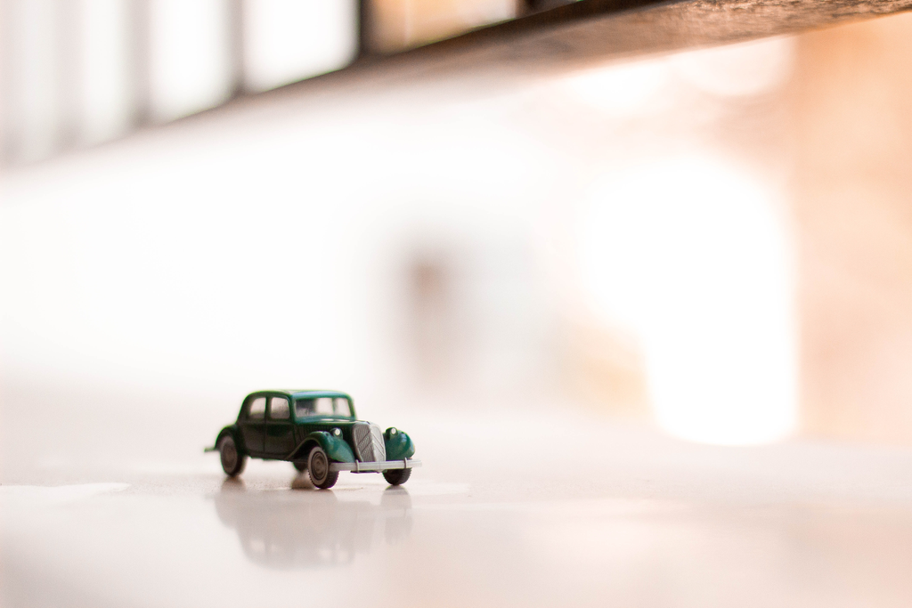

```r
# Load your libraries
library(mosaic)
library(DT)
library(car)
library(tidyverse)
library(pander)
```

## Background

When buying a car, it’s important to consider the resale value as well as how long you plan to keep the car you’ll eventually buy. Linear regression models can help predict resale values based on mileage. To demonstrate this, I’ll use a Two Lines Model multi-linear regression to compare the price depreciation of two car models.

### Hide Data

A dataset for car prices has been provided for analysis by Brigham Young University - Idaho.

### Show Data

The dataset includes observations for 32 models, so we’ll pick the model and trim with the smallest range in observed prices. I’ll limit our search to sedans since different car types certainly depreciate at different rates.

#### Original Data

```r
datatable(CarPrices)
```

|  | Price | Mileage | Make | Model | Trim | Type | Cylinder | Liter | Doors | Cruise | Sound | Leather |
| --- | --- | --- | --- | --- | --- | --- | --- | --- | --- | --- | --- | --- |
| 1 | 17314.10313 | 8221 | Buick | Century | Sedan 4D | Sedan | 6 | 3.1 | 4 | 1 | 1 | 1 |
| 2 | 17542.03608 | 9135 | Buick | Century | Sedan 4D | Sedan | 6 | 3.1 | 4 | 1 | 1 | 0 |
| 3 | 16218.84786 | 13196 | Buick | Century | Sedan 4D | Sedan | 6 | 3.1 | 4 | 1 | 1 | 0 |
| 4 | 16336.91314 | 16342 | Buick | Century | Sedan 4D | Sedan | 6 | 3.1 | 4 | 1 | 0 | 0 |
| 5 | 16339.17032 | 19832 | Buick | Century | Sedan 4D | Sedan | 6 | 3.1 | 4 | 1 | 0 | 1 |
| 6 | 15709.05282 | 22236 | Buick | Century | Sedan 4D | Sedan | 6 | 3.1 | 4 | 1 | 1 | 0 |
| 7 | 15230.00339 | 22576 | Buick | Century | Sedan 4D | Sedan | 6 | 3.1 | 4 | 1 | 1 | 0 |
| 8 | 15048.04218 | 22964 | Buick | Century | Sedan 4D | Sedan | 6 | 3.1 | 4 | 1 | 1 | 0 |
| 9 | 14862.09387 | 24021 | Buick | Century | Sedan 4D | Sedan | 6 | 3.1 | 4 | 1 | 0 | 1 |
| 10 | 15295.01827 | 27325 | Buick | Century | Sedan 4D | Sedan | 6 | 3.1 | 4 | 1 | 1 | 1 |

[output cut: 794 more lines]

#### Cleaned Data

The two models with the smallest range in price are the Cavalier LS Sport Sedan 4D and the Malibu Sedan 4D.

```r
Model_Price_Range <- CarPrices %>%
  select(Make, Model, Trim, Type, Price) %>%
  filter(Type == 'Sedan') %>%
  group_by(Model, Trim) %>%
  summarise(range = max(Price) - min(Price)) %>%
  arrange(range)

datatable(Model_Price_Range, options=list(lengthMenu = c(2,10,30)), extensions="Responsive")
```

|  | Model | Trim | range |
| --- | --- | --- | --- |
| 1 | Cavalier | LS Sport Sedan 4D | 1429.06605 |
| 2 | Malibu | Sedan 4D | 1839.12632 |
| 3 | Cobalt | Sedan 4D | 2200.05824 |
| 4 | Cobalt | LT Sedan 4D | 2252.6999 |
| 5 | AVEO | SVM Sedan 4D | 2332.164715 |
| 6 | Cobalt | LS Sedan 4D | 2387.80201 |
| 7 | AVEO | LT Sedan 4D | 2489.757965 |
| 8 | Bonneville | SE Sedan 4D | 2550.83146 |
| 9 | Lacrosse | CXS Sedan 4D | 2645.13565 |
| 10 | Century | Sedan 4D | 2679.94221 |

[output cut: 37 more lines]

```r
CarPrices2 <- CarPrices %>%
  select(Price, Mileage, Make, Model, Trim, Type) %>%
  filter(Trim == 'LS Sport Sedan 4D' | Trim == 'Sedan 4D') %>%
  filter(Model == 'Cavalier' | Model == 'Malibu') %>%
  mutate(
    model_trim_id = case_when(
      Model == "Cavalier" & Trim == "LS Sport Sedan 4D" ~ 0,
      Model == "Malibu" & Trim == "Sedan 4D" ~ 1,
      Model == "Cavalier" & Trim == "Sedan 4D" ~ 2,
    )
  )

CarPrices2 <- CarPrices2 %>%
  filter(model_trim_id != 2) %>%
  select(Price, Mileage, Make, Model, Trim, Type)

datatable(CarPrices2, options=list(lengthMenu = c(10,30)))
```

|  | Price | Mileage | Make | Model | Trim | Type |
| --- | --- | --- | --- | --- | --- | --- |
| 1 | 14222.3054 | 8427 | Chevrolet | Cavalier | LS Sport Sedan 4D | Sedan |
| 2 | 14266.91258 | 8615 | Chevrolet | Cavalier | LS Sport Sedan 4D | Sedan |
| 3 | 14255.74768 | 16958 | Chevrolet | Cavalier | LS Sport Sedan 4D | Sedan |
| 4 | 13762.90145 | 18040 | Chevrolet | Cavalier | LS Sport Sedan 4D | Sedan |
| 5 | 14275.12764 | 18533 | Chevrolet | Cavalier | LS Sport Sedan 4D | Sedan |
| 6 | 13688.00011 | 18766 | Chevrolet | Cavalier | LS Sport Sedan 4D | Sedan |
| 7 | 13308.83375 | 20043 | Chevrolet | Cavalier | LS Sport Sedan 4D | Sedan |
| 8 | 14145.88099 | 20512 | Chevrolet | Cavalier | LS Sport Sedan 4D | Sedan |
| 9 | 12944.93875 | 21684 | Chevrolet | Cavalier | LS Sport Sedan 4D | Sedan |
| 10 | 12846.06159 | 27560 | Chevrolet | Cavalier | LS Sport Sedan 4D | Sedan |

[output cut: 10 more lines]

## The Model

The mathematical model for this Two-lines model is as follows:
$$\underbrace{Y_i}_{\text{Price}} = \overbrace{\beta_0 + \beta_1 \underbrace{X_{i1}}_{\text{Mileage}}}^{\text{Cavalier Line}} + \overbrace{\beta_2 \underbrace{X_{i2}}_{\text{1 if Malibu}} + \beta_3 \underbrace{X_{i1} X_{i2}}_{\text{Interaction}}}^{\text{Malibu Adjustments to Line}} + \epsilon_i$$
$$X_{2i} = \left\{\begin{array}{ll} 1 & \text{if it's for the Malibu} \\ 0 & \text{if it's for the Cavalier} \end{array}\right.$$

$$\epsilon_i\sim N(0,\sigma^2)$$

This model breaks down into the following two mathematical models for each car model we’ll be working with:

| Vehicle | Value of $X_{i2}$ | Resulting Model |
| --- | --- | --- |
| Cavalier | $X_{i2} = 0$ | $Y_i = \beta_0 + \beta_1 X_{i1} + \epsilon_i$ |
| Malibu | $X_{i2} = 1$ | $Y_i = (\beta_0 + \beta_2) + (\beta_1 + \beta_3) X_{i1} + \epsilon_i$ |

We’ll use these resulting models to plot the data later on in the analysis.

## Hypothesis

If the y-intercepts are equal (or if $\beta_2 =0$), then the cars have the same average cost when brand new, but if they are not equal (or if $\beta_2 \neq 0$) than one car is generally more expensive than the other.

$$H_0: \beta_2 = 0 \quad \text{(Equal average cost when brand new)} \\
H_a: \beta_2 \neq 0 \quad \text{(Non-equal average cost when brand new)}$$

### The Equal Slopes Hypothesis

If the slopes are equal, then the cars depreciate at the same rate and so you’ll lose the same amount of money per mile no matter which car you pick.

$$H_0: \beta_3 = 0 \quad \text{(Equal rates of depreciation)} \\
H_a: \beta_3 \neq 0 \quad \text{(Non-equal rates of depreciation)}$$

## Analysis

### Test for Equal Slopes

When we conduct a multi-linear regression on this data, we return the following information.

```r
lmout <- lm(Price ~ Mileage + Model + Mileage:Model,
            data = CarPrices2)
summary(lmout) %>% pander
```

|  | Estimate | Std. Error | t value | Pr(>\|t\|) |
| --- | --- | --- | --- | --- |
| **(Intercept)** | 15048 | 414.7 | 36.29 | 8.507e-17 |
| **Mileage** | -0.07124 | 0.02214 | -3.217 | 0.005381 |
| **ModelMalibu** | 3491 | 592.8 | 5.889 | 2.286e-05 |
| **Mileage:ModelMalibu** | -0.03766 | 0.03163 | -1.191 | 0.2512 |

Fitting linear model: Price ~ Mileage + Model + Mileage:Model

| Observations | Residual Std. Error | $R^2$ | Adjusted $R^2$ |
| --- | --- | --- | --- |
| 20 | 381.7 | 0.9501 | 0.9407 |

```r
coef <- lmout$coefficients
#we'll need this to make lines on our plots
```

### Test for Equal y-Intercepts

We will need to remove $\beta_3$ in order to do the y-intercept hypothesis test since $\beta_3$ was statistically insignificant. All else remaining the same, the new model will be as follows:

| Vehicle | Value of $X_{i2}$ | Resulting Model |
| --- | --- | --- |
| Cavalier | $X_{i2} = 0$ | $Y_i = \beta_0 + \beta_1 X_{i1} + \epsilon_i$ |
| Malibu | $X_{i2} = 1$ | $Y_i = (\beta_0 + \beta_2) + (\beta_1) X_{i1} + \epsilon_i$ |

Here is the accompanying multi-linear regression for the new model.

```r
lmout2 <- lm(Price ~ Mileage + Model,
            data = CarPrices2)
summary(lmout2) %>% pander
```

|  | Estimate | Std. Error | t value | Pr(>\|t\|) |
| --- | --- | --- | --- | --- |
| **(Intercept)** | 15379 | 311.7 | 49.34 | 8.51e-20 |
| **Mileage** | -0.0897 | 0.01601 | -5.604 | 3.16e-05 |
| **ModelMalibu** | 2815 | 172.8 | 16.29 | 8.273e-12 |

Fitting linear model: Price ~ Mileage + Model

| Observations | Residual Std. Error | $R^2$ | Adjusted $R^2$ |
| --- | --- | --- | --- |
| 20 | 386.3 | 0.9457 | 0.9393 |

```r
coef2 <- lmout2$coefficients
```

The remaining $\beta$ values are all significant and since $\beta_2$ (or model) has a p-value of 8.273e-12 we can conclude that we have sufficient evidence to accept the alternative hypothesis and that the starting prices of the two models are not equal to one another.

Let’s visualize what we’ve found.

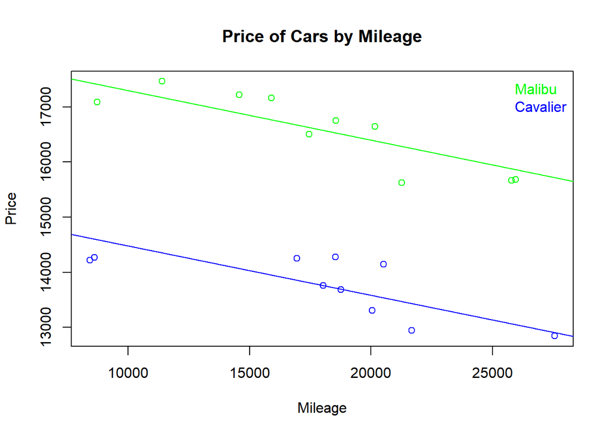

```r
palette(c("green","blue"))

plot(Price ~ Mileage,
     data = CarPrices2,
     col = Model,
     main = "Price of Cars by Mileage"
    )

# Add regression line
abline(a=coef2[1],
       b=coef2[2],
       col="blue")
abline(a=coef2[1] + coef2[3],
       b=coef2[2],
       col="green")

# Add legend:
  legend("topright",
         col = palette(),
         legend = c("Malibu",
                    "Cavalier"),
         bty="n",
         text.col = palette())
```

As we can see, our above conclusions are correct: the slopes do look approximately equal and the two cars clearly don’t have the same price when they are brand new.

### Assumptions Tests

Let’s check the assumptions.

````r
# This chunk uses ```{r, fig.height=3} to shrink the heigh of the graphs.
par(mfrow=c(1,3))
plot(lmout2, which=1)
qqPlot(lmout2$residuals)
````

```
## [1] 18  8
```

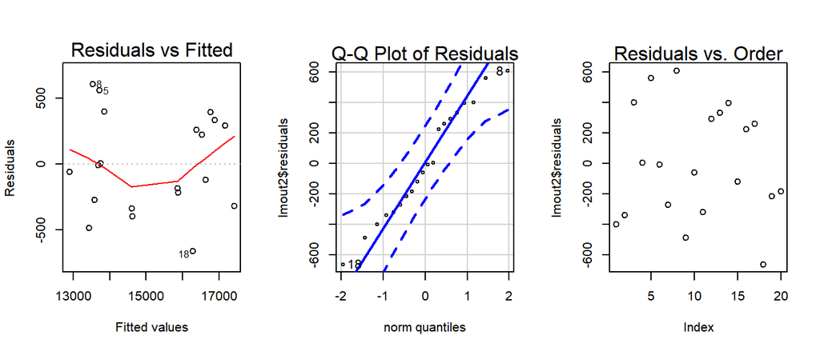

```r
mtext(side=3,text="Q-Q Plot of Residuals")
plot(lmout2$residuals)
mtext(side=3, text="Residuals vs. Order")
```

The assumptions have all been meet.

The Q-Q Plot of Residuals proves that we have a constant variance and that our data is normal (the third assumption).

We can assume that the X values (or mileage) has been measured without error (the fourth assumption).

Lastly, since the Residuals vs. Order plot doesn’t show a pattern, we can conclude that the error terms are independent of each other (assumption five).

## Conclusion

Since the cars depreciate at the same rate, buyers can purchase either one with the assumption that they’ll lose the least amount of money via mileage over either of these two options and (since the relationship between mileage and price is linear) they can safely assume that the depreciation rate will be constant for as long as they have the vehicle.